# Dengue no estado de SP: Gerador de Report e Dashboard com R Markdown

Rafael Bicudo Rosa

10 de agosto de 2018

## Gerador de Report e Dashboad

O objetivo deste trabalho é demonstrar como construir um gerador de dashboard a partir de uma série de inputs de uma fonte dados comum. Quando a estrutura dos registros se mantém ao longo dos anos, torna-se trivial originar um processo que automatize a análise dos dados. Este trabalho é interessante, principalmente, por ser mais uma ferramente no auxílio à tomada de decisão por gestores, pois é uma fonte rápida e fácil para melhor perceber a situação dos dados mais recentes disponíveis de forma agregada.

No caso, usaram-se informações obtidas no “datasus”, portal oficial de dados do Sistema Único de Saúde do governo brasileiro (http://tabnet.datasus.gov.br/cgi/deftohtm.exe?sinannet/cnv/dengueSP.def), sobre as ocorrências de dengue no estado de SP. A estrutura da tabela é composta por números anuais distribuídos por cidade e região dentro do estado.

Para a alcançar o objetivo do trabalho, os pacotes carregados abaixo serão usados para limpeza, organização e consolidação do dataframe final.

```r
# Pacotes necessarios
library(dplyr)
library(tidyr)
library(stringr)
```

## Estrutura dos dados

Como descrito acima, para garantir a execução, todos os inputs devem seguir um mesmo padrão. Ao realizar o download das tabelas anuais no site do datasus, identifica-se uma estrutura comum à vista no exemplo abaixo.

```
## # A tibble: 6 x 19
##   Município.de.notifi~ X3501.Grande.São.~ X3502.Araçatuba X3503.Araraquara
##   <chr>                             <int>           <int>            <int>
## 1 350010 Adamantina                    NA              NA               NA
## 2 350020 Adolfo                        NA              NA               NA
## 3 350030 Aguaí                         NA              NA               NA
## 4 350040 Águas da Pra~                 NA              NA               NA
## 5 350050 Águas de Lin~                 NA              NA               NA
## 6 350060 Águas de São~                 NA              NA               NA
## # ... with 15 more variables: X3504.Baixada.Santista <int>,
## #   X3505.Barretos <int>, X3506.Bauru <int>, X3507.Campinas <int>,
## #   X3508.Franca <int>, X3509.Marília <int>, X3510.Piracicaba <int>,
## #   X3511.Presidente.Prudente <int>, X3512.Registro <int>,
## #   X3513.Ribeirão.Preto <int>, X3514.São.João.da.Boa.Vista <int>,
## #   X3515.São.José.do.Rio.Preto <int>, X3516.Sorocaba <int>,
## #   X3517.Taubaté <int>, Total <int>
```

Repara-se como as linhas e as colunas estão completamente desorganizadas e com informações dispensáveis à análise. Os próximos passos, portanto, serão a limpeza e a organização dos dados.

## Data Cleaning

Para realizar a tarefa, usaremos dos pacotes carregados inicialmente. O dplyr é usado pelo seu dinamismo no uso dos pipes operators (%>%) e suas ferramentas de manipulação de dados; o tidyr por possuir a função gather cuja execução organiza a amostra em uma observação por linha; por fim, o stringr possue boas funções de manipulação de dados do tipo string, assim resolvendo o problema da “sujeira” nos dados.

```r
# Data Cleaning

  # tidy
  dengue_t <- dengue_exemplo_tbl %>%
    select(-Total) %>%
    gather(key = Regiao, value = Casos, -Município.de.notificação, na.rm = T)
  names(dengue_t) <- c('Municipio', 'Regiao', 'Casos')

  # Data Cleaning
  dengue_clean <- dengue_t

  # Municipio
  dengue_clean$Municipio <- str_replace_all(dengue_clean$Municipio, '[:digit:]', '')

  # Regiao
  dengue_clean$Regiao <- str_replace_all(dengue_clean$Regiao, '[:digit:]|[X.]', ' ') %>% str_trim()

  # Ano
  dengue_clean$Ano <- 2007

  head(dengue_clean)
```

```
## # A tibble: 6 x 4
##   Municipio      Regiao           Casos   Ano
##   <chr>          <chr>            <int> <dbl>
## 1 " Arujá"       Grande São Paulo    10  2007
## 2 " Barueri"     Grande São Paulo   728  2007
## 3 " Caieiras"    Grande São Paulo    13  2007
## 4 " Carapicuíba" Grande São Paulo    39  2007
## 5 " Cotia"       Grande São Paulo    35  2007
## 6 " Diadema"     Grande São Paulo    97  2007
```

Agora, tem-se o dataframe pronto para utilização.

## Automatização

O último passo para habilitar a análise reside em automatizar o processo visto acima para todas as informações disponíveis sempre que o script for executado. Para isso, usar-se-á a função abaixo descrita cujos inputs serão os arquivos csv contidos no diretório de trabalho e o ano extraído de seus nomes. O output é uma lista com todos os dataframes disponíveis no formato visto acima. Por fim, esses serão concatenados em um único objeto reunindo todas as tabelas.

```r
# Funcao para abertura e limpeza das tabelas anuais
Open.Dengue <- function (linha) {

  #Abertura do arquivo
  nome <- as.character(linha[1])
  dengue <- read.csv(nome, sep = ';', skip = 3, stringsAsFactors = F, na.strings
                     = '-', header = T, blank.lines.skip = TRUE)
  dengue_tbl <- dengue %>% as.tbl() %>% slice(1:526)

  # Data Cleaning

  # tidy
  dengue_t <- dengue_tbl %>%
    select(-Total) %>%
    gather(key = Regiao, value = Casos, -Município.de.notificação, na.rm = T)
  names(dengue_t) <- c('Municipio', 'Regiao', 'Casos')

  # Data Cleaning
  dengue_clean <- dengue_t

  # Municipio
  dengue_clean$Municipio <- str_replace_all(dengue_clean$Municipio, '[:digit:]', '')

  # Regiao
  dengue_clean$Regiao <- str_replace_all(dengue_clean$Regiao, '[:digit:]|[X.]', ' ') %>% str_trim()

  # Ano
  ano <- as.numeric(linha[2])
  dengue_clean$Ano <- ano
  return(dengue_clean)
}

# Vetor com os arquivos a serem gerados
dengue_arquivos <- list.files(pattern = ".csv")
dengue_arquivos
```

```
## [1] "dengue_sp_2007.csv" "dengue_sp_2008.csv" "dengue_sp_2009.csv"
## [4] "dengue_sp_2010.csv" "dengue_sp_2011.csv" "dengue_sp_2012.csv"
```

```r
# Vetor com os anos a serem usados na funcao
dengue_anos <- extract_numeric(dengue_arquivos)
```

```
## extract_numeric() is deprecated: please use readr::parse_number() instead
```

```r
# Lista com ambos
dengue_lista <- data.frame(df=dengue_arquivos, ano=dengue_anos, stringsAsFactors = F)

# Lista com dataframes
dengue_dfs_lista <- apply(dengue_lista, 1, Open.Dengue)

# Juncao dos dfs
dengue_df <- do.call(rbind, dengue_dfs_lista)
head(dengue_df)
```

```
## # A tibble: 6 x 4
##   Municipio      Regiao           Casos   Ano
##   <chr>          <chr>            <int> <dbl>
## 1 " Arujá"       Grande São Paulo    10  2007
## 2 " Barueri"     Grande São Paulo   728  2007
## 3 " Caieiras"    Grande São Paulo    13  2007
## 4 " Carapicuíba" Grande São Paulo    39  2007
## 5 " Cotia"       Grande São Paulo    35  2007
## 6 " Diadema"     Grande São Paulo    97  2007
```

```r
glimpse(dengue_df)
```

```
## Observations: 2,832
## Variables: 4
## $ Municipio <chr> " Arujá", " Barueri", " Caieiras", " Carapicuíba", "...
## $ Regiao    <chr> "Grande São Paulo", "Grande São Paulo", "Grande São ...
## $ Casos     <int> 10, 728, 13, 39, 35, 97, 387, 10, 15, 1, 21, 928, 52...
## $ Ano       <dbl> 2007, 2007, 2007, 2007, 2007, 2007, 2007, 2007, 2007...
```

## Report

Com todo o método de preparação dos dados explicado, passar-se-á a geração do report. Ele consiste em uma série de 4 plots que demonstram a evolução do número total de casos no estado, como as regiões estão em relação à media do período, quais são as regiões com as maiores médias históricas e, por último, como essas médias se comportaram ao longo do período analisado. Todos serão gerados a partir do pacote mais usual de vizualização do R: ggplot2, que usa a abordagem de gráficos como uma série de camadas, e o RColorBrewer para disponibilizar paletes de cor.

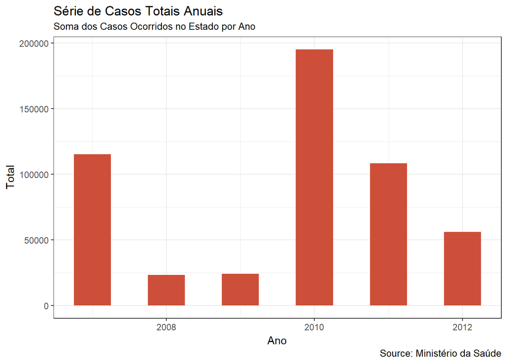

```r
## EDA

# Pacotes
library(ggplot2)
library(RColorBrewer)

# Plot 1 do avanco dos casos totais ao longo dos anos <- size tá ruim
dengue_df %>%
  group_by(Ano) %>%
  summarise(Total_ano = sum(Casos)) %>%
  ggplot(aes(x = Ano, y = Total_ano)) +
  geom_bar(stat="identity", width=.5, fill="tomato3") +
  labs(title="Série de Casos Totais Anuais",
       subtitle="Soma dos Casos Ocorridos no Estado por Ano",
       caption="Source: Ministério da Saúde",
       y='Total') +  # title and caption
  theme_bw() #+
```

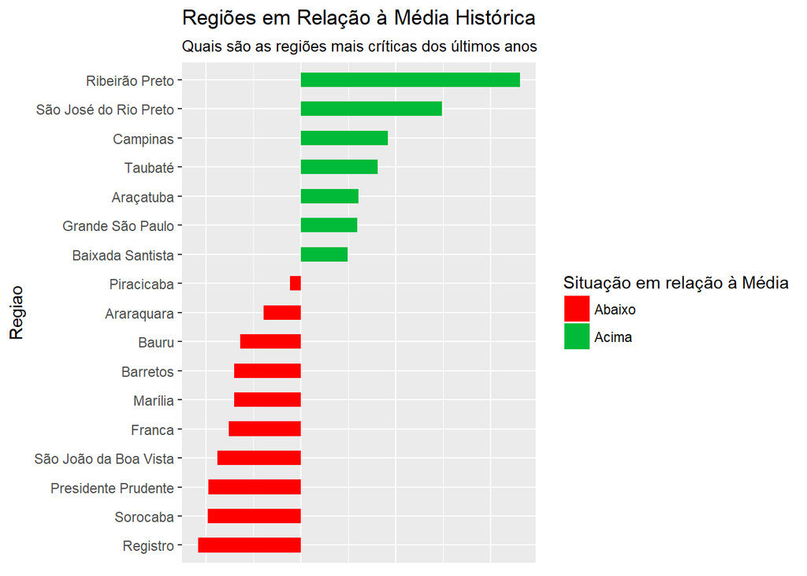

```r
  #theme(axis.text.x = element_text(angle = 90, vjust=0.5),  # rotate x axis text
  #      panel.grid.minor = element_blank())

# Df com as regioes e a sua quantidade de casos
dengue_df_regioes <- dengue_df %>%
  group_by(Regiao, Ano) %>%
  summarise('Total' = sum(Casos))

# Df para construcao do plot comparativo de quanto as regioes estao em relacao a media e consecutivo plot 2
dengue_df_m <- dengue_df_regioes %>%
  group_by(Regiao) %>%
  summarise(Media = mean(Total)) %>%
  mutate(Media_s = scale(Media)) %>%
  mutate(Situacao = ifelse(Media_s > 0, 'Acima', 'Abaixo'))

dengue_df_m %>%
  arrange(Media) %>%
  mutate(Regiao = factor(Regiao, levels = Regiao,ordered = TRUE)) %>%
  ggplot(aes(x=Regiao, y=Media_s, label=Media_s)) +
  geom_bar(stat='identity', aes(fill=Situacao), width=.5)  +
  scale_fill_manual(name="Situação em relação à Média",
                    labels = c("Abaixo", "Acima"),
                    values = c("Abaixo"="#FF0000", "Acima" = "#00ba38")) +
  labs(subtitle="Quais são as regiões mais críticas dos últimos anos",
       title= "Regiões em Relação à Média Histórica") +
  coord_flip() +
  theme(axis.title.x=element_blank(),
        axis.text.x=element_blank(),
        axis.ticks.x=element_blank())
```

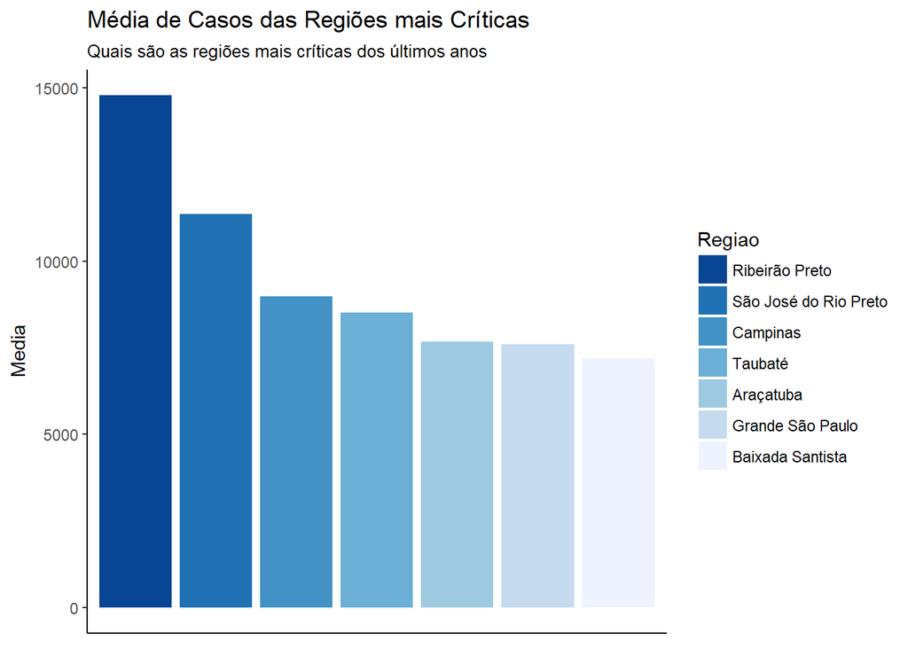

```r
# Df com as regioes mais críticas e plot 3 consecutivo
regioes_maisCasos <- dengue_df_regioes %>%
  group_by(Regiao) %>%
  summarise(Media = mean(Total)) %>%
  arrange(desc(Media)) %>%
  head(n = 7)

regioes_maisCasos %>%
  mutate(Regiao = factor(Regiao, levels = Regiao,ordered = TRUE)) %>%
  ggplot(aes(x = Regiao, y = Media, fill = Regiao)) +
  geom_bar(stat = 'identity') +
  labs(subtitle="Quais são as regiões mais críticas dos últimos anos",
       title= "Média de Casos das Regiões mais Críticas") +
  scale_fill_brewer(direction = -1) +
  theme_classic() +
  theme(axis.title.x=element_blank(),
      axis.text.x=element_blank(),
      axis.ticks.x=element_blank())
```

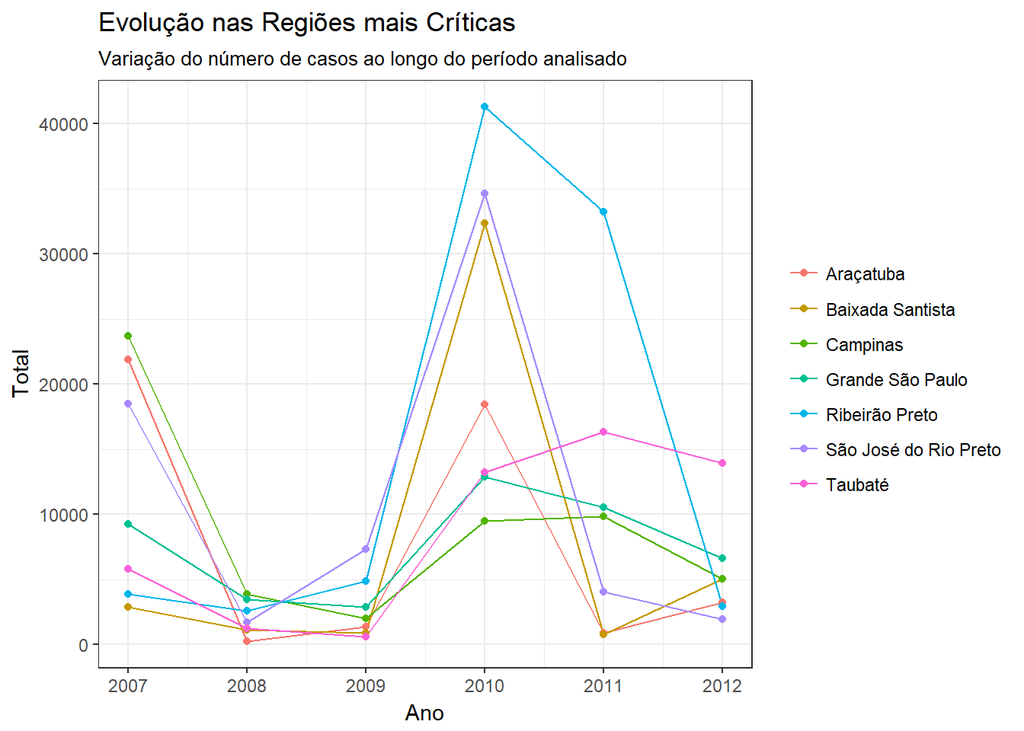

```r
# Variacao dos casos do dengue nas 6 maiores regioes e seu plot 4
dengue_df_regioes %>%
  inner_join(regioes_maisCasos) %>%
  ggplot(aes(x = Ano, y = Total, group = Regiao, color = Regiao)) +
  geom_line() +
  geom_point() +
  labs(title="Evolução nas Regiões mais Críticas",
       subtitle="Variação do número de casos ao longo do período analisado",
       color=NULL) +
  theme_bw()
```

## Dashboard interativo do ano mais recente

Por fim, tem-se a elaboração de uma plotagem interativa do estado com o mapeamento da quantidade de casos por região no ano mais recente do diretório. Utilizam-se os pacotes ggmap, para obtenção das coodenadas geográficas dos locais, e o leaflet para reprodução do mapa interativo.

```r
# Carregando pacotes necessários
library(ggmap)
library(leaflet)

# df para geracao do dashboard
dengue_df_dashB <- dengue_df_regioes %>%
  filter(Ano == max(unique(dengue_df_regioes$Ano)))

# Gerando os mapas de cada cidade de SP
longlat <- geocode(dengue_df_dashB$Regiao) %>%
  mutate(loc = unique(dengue_df_regioes$Regiao))
```

```
## .Information from URL : http://maps.googleapis.com/maps/api/geocode/json?address=Presidente%20Prudente&sensor=false
## .Information from URL : http://maps.googleapis.com/maps/api/geocode/json?address=Registro&sensor=false
## .Information from URL : http://maps.googleapis.com/maps/api/geocode/json?address=Ribeir%C3%A3o%20Preto&sensor=false
## .Information from URL : http://maps.googleapis.com/maps/api/geocode/json?address=S%C3%A3o%20Jo%C3%A3o%20da%20Boa%20Vista&sensor=false
```

```r
# Criacao do df com ano mais recente e geolocalizacoes obtidas
dengue_df_dashB  %>%
  left_join(longlat, by = c("Regiao" = "loc")) %>%
  mutate(LatLon = paste(lat, lon, sep = ":")) -> criacao_mapa

# Formatando a saída e gerando um movo dataframe chamado long_formapping
num_de_vezes_repetir <- criacao_mapa$Total
criacao_mapa <- criacao_mapa[rep(seq_len(nrow(criacao_mapa)),
                                  num_de_vezes_repetir),]

# Gerando o mapa com o dataframe
leaflet(criacao_mapa) %>%
  addTiles() %>%
  addMarkers(clusterOptions = markerClusterOptions())
```

```
## Assuming "lon" and "lat" are longitude and latitude, respectively
```

[interactive chart not shown]